# Intro to DS - Linear Model part I

Edwin Lo, GWU Intro to Data Science DATS 6101

2022-03-19

# HW assignment

## Linear model - quantitative regressors

### Question 1

**Import the data, call it `bikeorig.`**  
The `Date` variable is probably imported as factor level variable. In any case, let us remove `Date`, `Casual.Users`, and `Registered.Users` in the dataset and save it as a new datafame, call it `bike`. How many variables are in `bike`? How many of them are imported as `int`? Feel free to rename longer variable names into shorter ones for convenience.

```r
bikeorig = data.frame(read.csv('bikedata.csv', sep=',',
                                header=T, fill=T))
bike <- bikeorig[, c(-1, -12, -13)]
cnames <- colnames(bike)
cnames[4] <- 'Day'
cnames[5] <- 'Workday'
cnames[6] <- 'Weather'
colnames(bike) <- cnames

n_int <- 0
for(cname in colnames(bike)){
  if(class(bike[, cname]) == 'integer')
  {
    n_int = n_int + 1
  }
}
```

There are 11 variables in the bike dataframe and out of those, 9 were imported as an integer.

### Question 2

**Select only the subset with `Hour` equal 16 only. Call it `bike16`**  
These are the afternoon rush hour data. How many observations are there?

```r
bike16 <- bike[bike[, 'Hour']==16,]
```

There are 730 observations in the rush hour subset.

### Question 3

**Before building any models, we should make sure the variables are set up properly.**  
(This problem is solved for you. Codes are given below.)  
Which ones should be recorded as categorical? Convert them now before we proceed to the model building.

Note: After converting, the correlation function `cor()` will not work with categorical/factor variables. I would keep the original `bike16` dataframe as numeric, and use that to find the correlation matrix. Although technically correlation between categorical and numeric variables are not well defined in general, we can still get some useful information if the categorical variable is at least at ordinal level. See future discussion on using “Pearson” vs “Spearman” methods for correlation tests.

While the `cor()` function does not accept categorical variables (and therefore we cannot use it for `corrplot()`), the `lattice::pairs()` function does not complain about categorical columns. We can still use it to get a visual distribution of data values from it.

```r
bike_final = bike16
bike_final$Season = factor(bike16$Season)
bike_final$Holiday = factor(bike16$Holiday)
bike_final$Day = factor(bike16$Day)
bike_final$Workday = factor(bike16$Workday)
bike_final$Weather = factor(bike16$Weather)
str(bike_final)
```

[output not shown]

We decided to convert these variables into categorical (factor):  
`Season`, `Holiday`, `Day`, `Workday`, and `Weather`. Notice that the dataframe `bike16` still has all variables numerical, while the df `bike_final` include categorical columns that we just converted.

### Question 4

**Make a `pairs()` plot with all the variables (quantitative and qualitative).**

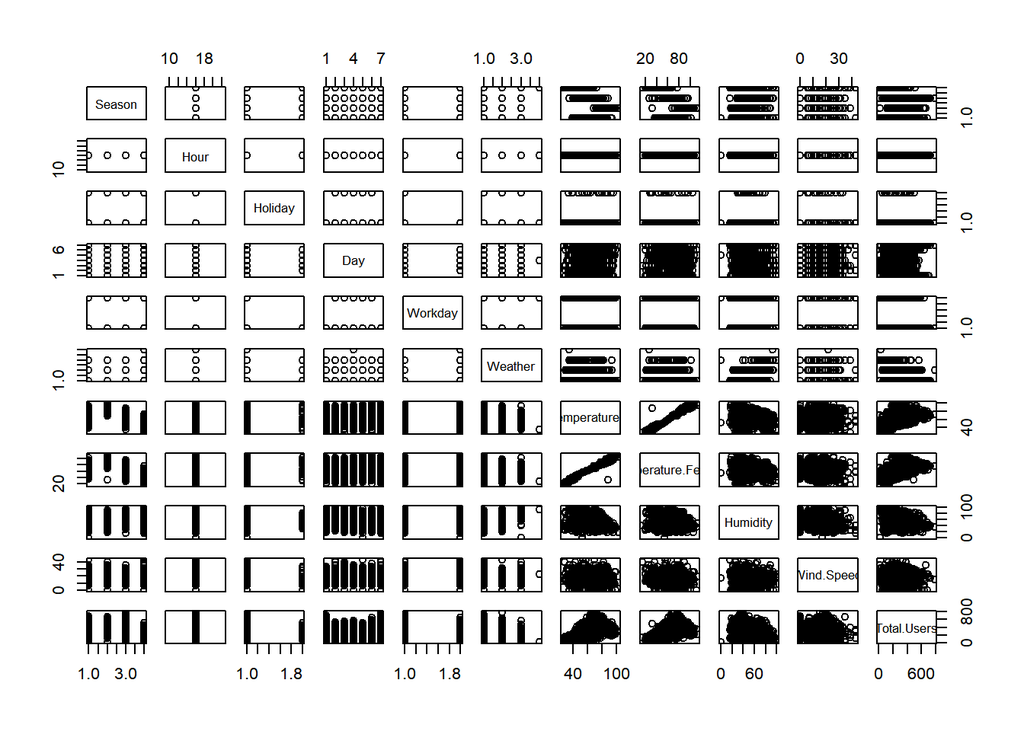

```r
pairs(bike_final)
```

### Question 5  
**Make a `corrplot()` with only the numerical variables.**  
You can either subset the df with only numerical variables first, then create the create the cor-matrix to plot. Or you can create the cor-matrix from `bike16`, then select select out the portion of the matrix that you want. Use options that shows well the relationships between different variables.

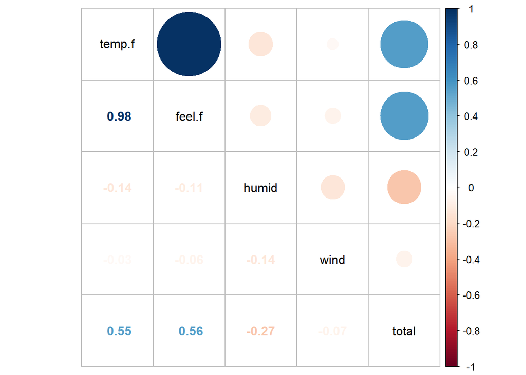

```r
# num_cols <- NULL
# for(cname in colnames(bike16))
# {
#   if(class(bike16[, cname])=='numeric')
#   {
#     num_cols <- c(num_cols, cname)
#   }
# }
# I am confused when you asked only to use numeric variables since temp.f and feels like are the only two variables with numerical data type so I  thought you meant to use variables that are non-factors instead of numeric what I interpret as float.

num_cols <- c('Temperature.F', 'Temperature.Feels.F', 'Humidity', 'Wind.Speed', 'Total.Users')
new_cols <- c('temp.f', 'feel.f', 'humid', 'wind', 'total')

bike16.num_subset <- bike16[, num_cols]
colnames(bike16.num_subset) <- new_cols

bike_cormatrix <- corrplot::corrplot.mixed(cor(bike16.num_subset),
                                     lower = "number",
                                     upper = "circle",
                                     tl.col = "black")
```

I am confused when you asked only to use numeric variables since temp.f and feels like are the only two variables with numerical data type so I thought you meant to use variables that are non-factors instead of numeric what I interpret as float.

### Question 6

**By using numerical variables only, build a linear model with 1 independent variable to predict the `Total Users`.**  
Choose the variable with the strongest correlation coefficient. Make some short comments on the coefficient values, their p-values, and the multiple R-squared value.

```r
model1 <- lm(Total.Users~Temperature.Feels.F, data=bike_final)
summary(model1)
```

```
##
## Call:
## lm(formula = Total.Users ~ Temperature.Feels.F, data = bike_final)
##
## Residuals:
##    Min     1Q Median     3Q    Max
## -308.7  -88.9   -5.6   78.7  428.6
##
## Coefficients:
##                     Estimate Std. Error t value Pr(>|t|)
## (Intercept)           44.530     15.510    2.87   0.0042 **
## Temperature.Feels.F    4.024      0.223   18.05   <2e-16 ***
## ---
## Signif. codes:  0 '***' 0.001 '**' 0.01 '*' 0.05 '.' 0.1 ' ' 1
##
## Residual standard error: 124 on 728 degrees of freedom
## Multiple R-squared:  0.309,  Adjusted R-squared:  0.308
## F-statistic:  326 on 1 and 728 DF,  p-value: <2e-16
```

**Coefficient interpretation**  
1. An intercept value of 44.53 represents the average number of users when the feel like temperature is $0^{\circ}F$.  
2. A coefficient value for Temperature.Feels.F represents for every increase in this value, the total users increases by 4.024

**Comment on p-value**  
The p value for variable Temperature.Feels.F represents its relationship with variable total users is statistically significant.

**Comment on Multiple R squared**  
From my understanding, in bivariate linear regression model, both Multiple $R^2$ and $R^2$ are the same. While Multiple R refers to the coefficient of multiple correlation between the independent and the dependent variables, its squared version represents the coefficient of determination.  
The value of 0.309 *(I couldn’t retrieve this dynamically)* means $\sim 30\%$ of the variance in the dependent variable can be predicted by the independent variable. In other words, it represents how good the model fits the data.

### Question 7

**Next, add a second variable to the model.**  
Choose the variable with the next strongest correlation, but avoid using obviously collinear variables. When you have the model, check the VIF values. If the VIF is higher than 5, discard this model, and try the variable with the next strongest correlation until you find one that works (ideally with vif’s <5, or if you have to, allow vif up to 10). Again, comment on the coefficient values, their p-values, and the multiple R-squared value.  
**Temperature.Feels.F vs Temperature.F**

```r
vif_values <- ezids::xkablevif(lm(Total.Users ~ Temperature.Feels.F+Temperature.F, data=bike_final[, num_cols]))
vif_values
```

VIFs of the model

| Temperature.F | Temperature.Feels.F |
| --- | --- |
| 31.7 | 31.7 |

**Temperature.Feels.F vs Humidity**

```r
vif_values <- ezids::xkablevif(lm(Total.Users ~ Temperature.Feels.F+Humidity, data=bike_final[, num_cols]))
vif_values
```

VIFs of the model

| Humidity | Temperature.Feels.F |
| --- | --- |
| 1.01 | 1.01 |

**Temperature.Feels.F vs Wind.Speed**

```r
vif_values <- ezids::xkablevif(lm(Total.Users ~ Temperature.Feels.F+Wind.Speed, data=bike_final[, num_cols]))
vif_values
```

VIFs of the model

| Temperature.Feels.F | Wind.Speed |
| --- | --- |
| 1 | 1 |

We can see from the above tables that variables Temperature.Feels.F and Temperature.F have high multicollinearity. Since Humidity has the next strongest correlation coefficient, it is chosen as the second variable for the second model.

```r
model2 <- lm(Total.Users ~ Temperature.Feels.F+Humidity, data=bike_final)
summary(model2)
```

```
##
## Call:
## lm(formula = Total.Users ~ Temperature.Feels.F + Humidity, data = bike_final)
##
## Residuals:
##    Min     1Q Median     3Q    Max
## -324.5  -83.7   -8.9   73.7  407.5
##
## Coefficients:
##                     Estimate Std. Error t value Pr(>|t|)
## (Intercept)          138.712     20.001    6.94  9.0e-12 ***
## Temperature.Feels.F    3.859      0.217   17.78  < 2e-16 ***
## Humidity              -1.678      0.236   -7.12  2.6e-12 ***
## ---
## Signif. codes:  0 '***' 0.001 '**' 0.01 '*' 0.05 '.' 0.1 ' ' 1
##
## Residual standard error: 120 on 727 degrees of freedom
## Multiple R-squared:  0.354,  Adjusted R-squared:  0.352
## F-statistic:  199 on 2 and 727 DF,  p-value: <2e-16
```

**Comment on p-value**  
All of the independent variables chosen so far are statistically significant in their relationship with the dependent variable. In other words, we reject the null hypothesis in favor of the alternate hypothesis. It makes sense why there is also a jump in Multiple $R^2$ value.

### Question 8

**We will try one more time as in the previous question, to add a third variable in our model.**  
**Temperature.Feels+Humidity vs Wind.Speed**

```r
vif_values <- ezids::xkablevif(lm(Total.Users ~ Temperature.Feels.F+Humidity+Wind.Speed, data=bike_final))
vif_values
```

VIFs of the model

| Humidity | Temperature.Feels.F | Wind.Speed |
| --- | --- | --- |
| 1.02 | 1.03 | 1.02 |

**Temperature.Feels+Humidity vs Temperature.F**

```r
vif_values <- ezids::xkablevif(lm(Total.Users ~ Temperature.Feels.F+Humidity+Temperature.F, data=bike_final))
vif_values
```

VIFs of the model

[output not shown]

```r
model3 <- lm(Total.Users ~ Temperature.Feels.F+Humidity+Wind.Speed, data=bike_final)
summary(model3)
```

```
##
## Call:
## lm(formula = Total.Users ~ Temperature.Feels.F + Humidity + Wind.Speed,
##     data = bike_final)
##
## Residuals:
##    Min     1Q Median     3Q    Max
## -327.3  -82.7   -9.8   75.7  405.9
##
## Coefficients:
##                     Estimate Std. Error t value Pr(>|t|)
## (Intercept)          162.710     23.006    7.07  3.6e-12 ***
## Temperature.Feels.F    3.823      0.217   17.61  < 2e-16 ***
## Humidity              -1.750      0.237   -7.37  4.8e-13 ***
## Wind.Speed            -1.137      0.543   -2.10    0.036 *
## ---
## Signif. codes:  0 '***' 0.001 '**' 0.01 '*' 0.05 '.' 0.1 ' ' 1
##
## Residual standard error: 119 on 726 degrees of freedom
## Multiple R-squared:  0.358,  Adjusted R-squared:  0.355
## F-statistic:  135 on 3 and 726 DF,  p-value: <2e-16
```

**Coefficient interpretation**  
1. An intercept value of 162.71 represents the average number of users when the feel like temperature and wind speed are both $0^{\circ}F$.  
2. The estimated coefficient value for Temperature.Feels.F represents for every increase in this value, the total users increases by 3.823  
3. The estimated coefficient value for Humidity represents for every increase in this value, the total users decreases by -1.75 as this is negatively correlated with variable Total.Users.  
4. The estimated coefficient value for Wind.Speed represents for every increase in this value, the total users decreases by -1.137 as this is negatively correlated with variable Total.Users.

**Comment on Multiple R squared**  
Compared to the previous model, the Multiple $R^2$ has the slightest of improvement as the p value for Wind.Speed is 0.036, which is closer to 0.05 at 95% confidence. This means the variable is less significant to the response variable in the model and is also represented by the significance code $*$.

### Question 9

**For the 3-variable model you found, find the confidence intervals of the coefficients.**

```r
stats::confint(model3)
```

```
##                      2.5 %   97.5 %
## (Intercept)         117.54 207.8765
## Temperature.Feels.F   3.40   4.2498
## Humidity             -2.22  -1.2833
## Wind.Speed           -2.20  -0.0718
```

### Question 10

**Use ANOVA to compare the three different models you found.**  
You have found three different models. Use ANOVA test to compare their residuals. What conclusion can you draw?

```r
a_variance_analysis <- anova(model1, model2, model3)
a_variance_analysis
```

```
## Analysis of Variance Table
##
## Model 1: Total.Users ~ Temperature.Feels.F
## Model 2: Total.Users ~ Temperature.Feels.F + Humidity
## Model 3: Total.Users ~ Temperature.Feels.F + Humidity + Wind.Speed
##   Res.Df      RSS Df Sum of Sq     F  Pr(>F)
## 1    728 11133872
## 2    727 10407664  1    726209 50.96 2.3e-12 ***
## 3    726 10345083  1     62580  4.39   0.036 *
## ---
## Signif. codes:  0 '***' 0.001 '**' 0.01 '*' 0.05 '.' 0.1 ' ' 1
```

As already commented for Model3, there is not much improvement from Model2 to Model3 as the p value is 0.036 that is somewhat closer to 0.05 at 95% confidence level. However, it is still considered significant as the p value is lesser than 0.05.  
From Model1 to Model2, there is certainly substantial statistical significance as the code is $***$  
P.S. ANOVA on three different models compares their residuals to determine the statistical significance.